# R Notebook

Import the data and split in train-set and test-set

```r
library(haven)
data <- read_dta("data/zambia_height92.dta")
head(data)
```

| zscore | c_gender | c_breastf | c_age | m_agebirth | m_height | m_bmi | m_education | m_work | region | district |
| --- | --- | --- | --- | --- | --- | --- | --- | --- | --- | --- |
| -159 | 0 | 0 | 4 | 24.66667 | 148.9 | 21.83 | 2 | 0 | 1 | 81 |
| -205 | 0 | 13 | 26 | 22.83333 | 148.9 | 21.83 | 2 | 0 | 1 | 81 |
| -192 | 1 | 18 | 56 | 15.33333 | 169.2 | 20.43 | 2 | 1 | 1 | 81 |
| -146 | 1 | 0 | 6 | 21.50000 | 162.2 | 22.27 | 3 | 0 | 1 | 81 |
| 69 | 0 | 6 | 54 | 17.50000 | 162.2 | 22.27 | 3 | 0 | 1 | 81 |
| -80 | 0 | 0 | 1 | 30.91667 | 162.8 | 22.86 | 2 | 0 | 1 | 81 |

```r
#split data in train and test set
set.seed(123)
train <- sample(1:nrow(data), 0.85*nrow(data))

test <- setdiff(1:nrow(data), train)

train_data <- data[train,]
test_data <- data[test,]
```

Check for missing values (SPOILER: NO MISSING VALUES)

```r
sum(is.na(train_data))
```

```
[1] 0
```

Cast of variables’ type

```r
#check if all zscore values are integers
sum(train_data$zscore - as.integer(train_data$zscore))
```

```
[1] 0
```

```r
#cast of zscore to integer
train_data$zscore <- as.integer(train_data$zscore)

#factorize gender
train_data$c_gender <- as.factor(train_data$c_gender)

#cast c_breastf as integer
train_data$c_breastf <- as.integer(train_data$c_breastf)

#cast c_age as integer
train_data$c_age <- as.integer(train_data$c_age)

#NOTE: to have the month of birth in m_agebirth calculate: decimal_part * 12

#factorize m_education
train_data$m_education <- as.factor(train_data$m_education)

#factorize m_work
train_data$m_work <- as.factor(train_data$m_work)

#factorize region
train_data$region <- as.factor(train_data$region)

#factorize district
train_data$district <- as.factor(train_data$district)
```

Now let’s dive into each variable.

First we plot the distribution of the zscore variable.

```r
hist(train_data$zscore, breaks = 20, col = "lightblue", main = "Histogram of zscore", xlab = "zscore", freq = FALSE)
#add the normal curve with mean and sd of zscore
curve(dnorm(x, mean = mean(train_data$zscore), sd = sd(train_data$zscore)), col = "red", lwd = 2, add = TRUE)
```

```r
#add the vertical dotted line at the mean, add it to the legend
abline(v = mean(train_data$zscore), col = "blue", lwd = 2, lty = 2)
legend("topright", c("Normal curve", "Mean"), col = c("red", "blue"), lwd = c(2, 2), lty = c(1, 2), cex = 1.5)
```

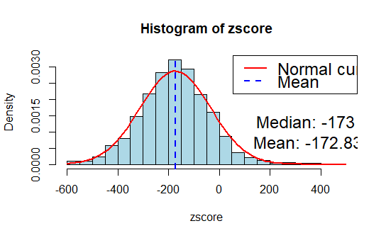

```r
# Write the median and mean values to check if they're similar
text(350, 0.001, paste("Median:", round(median(train_data$zscore), 2), "\nMean:", round(mean(train_data$zscore), 2)), cex = 1.5)
```

Notice how this variable seems to follow a normal distribution. Also the mean (and then the median) is significally lower than 0: this is a measure of how the american population is healthier.

Let’s plot the correlation matrix for continuous variables

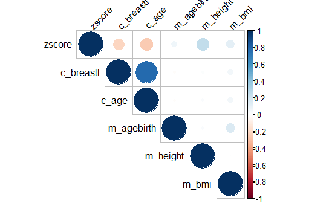

```r
library(corrplot)
#correlation matrix for continuous variables
cor_matrix <- cor(train_data[,c("zscore", "c_breastf", "c_age", "m_agebirth", "m_height", "m_bmi")])
corrplot(cor_matrix, method = "circle", type = "upper", tl.col = "black", tl.srt = 45)
```

We would expect that the older the child gets, the higher the zscore. This seems not true based on the correlation matrix. We will check this later. This holds also for the amount of breasfeeding months.

Now we study the gender variable

```r
#barplot of c_gender
table(train_data$c_gender)
```

```
   0    1
1933 1824
```

The c_gender variable is quite balanced, even tho there are a bit more females.

```r
#plot the previous distribution (zscore) for c_gender=0 and c_gender=1

hist(train_data$zscore[train_data$c_gender==0], breaks = 20, col = rgb(0,0,1,1/4), main = "Histogram of zscore", xlab = "zscore", freq = FALSE)
hist(train_data$zscore[train_data$c_gender==1], breaks = 20, col = rgb(1,0,0,1/4), main = "Histogram of zscore", xlab = "zscore", freq = FALSE, add = TRUE)
```

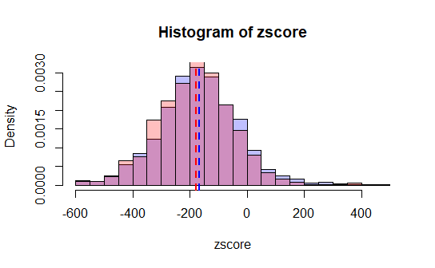

```r
# add the mean line for both distributions
abline(v = mean(train_data$zscore[train_data$c_gender==0]), col = "blue", lwd = 2, lty = 2)
abline(v = mean(train_data$zscore[train_data$c_gender==1]), col = "red", lwd = 2, lty = 2)
```

This has to be corrected on shiny, for now it’s sufficient to see that the two distributions are quite similar.

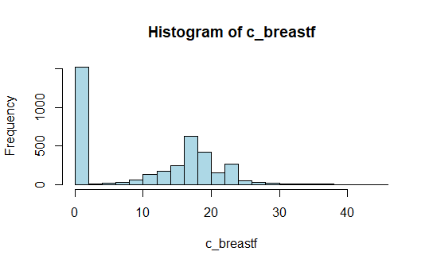

```r
#plot the distribution of the c_breastf variable
hist(train_data$c_breastf, breaks = 20, col = "lightblue", main = "Histogram of c_breastf", xlab = "c_breastf", freq = T)
```

There are a lot of children that have been breastfeed for 0 months.

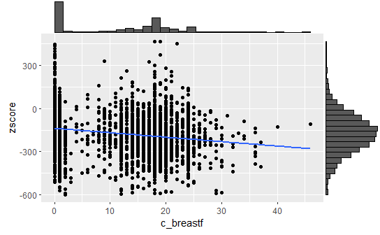

```r
library(ggplot2)
library(ggExtra)
#marginal plot of zscore and c_breastf

p <- ggplot(train_data, aes(x=c_breastf, y=zscore)) +
  geom_point() +
  theme(legend.position="none") +
  # add a regression line
  geom_smooth(method=lm, se=FALSE)

p1 <- ggMarginal(p, type="histogram")
p1
```

```r
cor.test(train_data$zscore, train_data$c_breastf)
```

```
    Pearson's product-moment correlation

data:  train_data$zscore and train_data$c_breastf
t = -13.162, df = 3755, p-value < 2.2e-16
alternative hypothesis: true correlation is not equal to 0
95 percent confidence interval:
 -0.2403705 -0.1792321
sample estimates:
       cor
-0.2100066
```

There doesn’t seem to be a correlation at eye, by looking at the plot, but if we perform a test we can see that there is a slight negative correlation between the variables, meaning that the more months a child has been breastfed, the lower the zscore (quite odd)

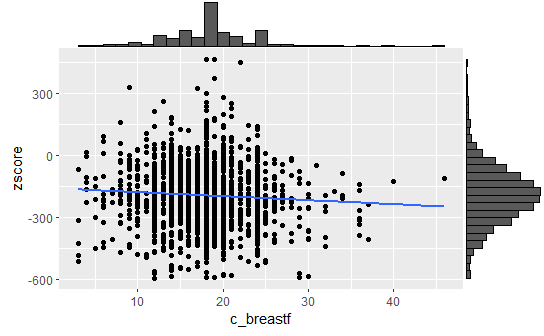

```r
library(dplyr)
#plot the marginal distribution of the zscore variable for c_breastf > 2

p <- train_data %>%
  filter(c_breastf > 2) %>%
  ggplot(., aes(x=c_breastf, y=zscore)) +
  geom_point() +
  theme(legend.position="none") +
  # add a regression line
  geom_smooth(method=lm, se=FALSE)

p2 <- ggMarginal(p, type="histogram")
p2
```

```r
cor.test(train_data$zscore[train_data$c_breastf > 2], train_data$c_breastf[train_data$c_breastf > 2])
```

```
    Pearson's product-moment correlation

data:  train_data$zscore[train_data$c_breastf > 2] and train_data$c_breastf[train_data$c_breastf > 2]
t = -3.1606, df = 2235, p-value = 0.001596
alternative hypothesis: true correlation is not equal to 0
95 percent confidence interval:
 -0.10785008 -0.02533101
sample estimates:
        cor
-0.06670461
```

By removing the observations relatively to children that have been breastfed for less than 2 months, we can see that the correlation is very close to 0.

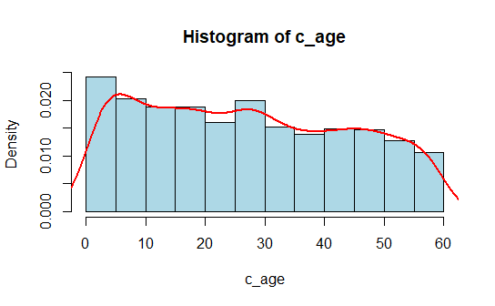

```r
#plot the distribution of c_age variable
hist(train_data$c_age, breaks = 20, col = "lightblue", main = "Histogram of c_age", xlab = "c_age", freq = F)
#add a density curve
lines(density(train_data$c_age), col = "red", lwd = 2)
```

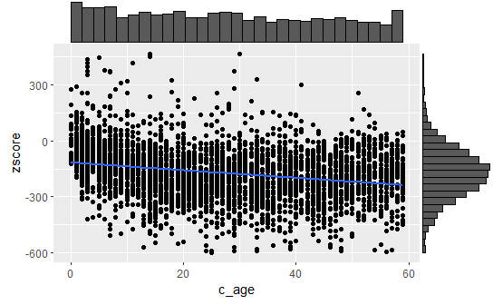

```r
#marginal plot of zscore and c_age
p<- ggplot(train_data, aes(x=c_age, y=zscore)) +
  geom_point() +
  theme(legend.position="none") +
  # add a regression line
  geom_smooth(method=lm, se=FALSE)

p3 <- ggMarginal(p, type="histogram")
p3
```

We expect that the older the child, the higher the zscore, but the plot doesn’t seem to show this. Let’s perform a test to see if there is a correlation between the two variables.

```r
cor.test(train_data$zscore, train_data$c_age)
```

```
    Pearson's product-moment correlation

data:  train_data$zscore and train_data$c_age
t = -15.942, df = 3755, p-value < 2.2e-16
alternative hypothesis: true correlation is not equal to 0
95 percent confidence interval:
 -0.2814887 -0.2215828
sample estimates:
       cor
-0.2517769
```

```r
#plot the distribution of m_agebirth variable
hist(train_data$m_agebirth, breaks = 20, col = "lightblue", main = "Histogram of m_agebirth", xlab = "m_agebirth", freq = F)
#add a density curve
lines(density(train_data$m_agebirth), col = "red", lwd = 2)
```

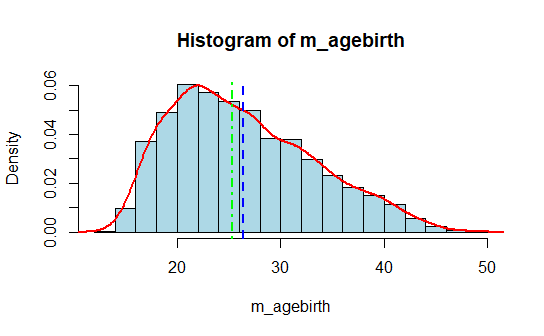

```r
#add the mean line and the median line
abline(v = mean(train_data$m_agebirth), col = "blue", lwd = 2, lty = 2)
abline(v = median(train_data$m_agebirth), col = "green", lwd = 2, lty = 4)
```

```r
#plot the distribution of m_height variable
hist(train_data$m_height, breaks = 20, col = "lightblue", main = "Histogram of m_height", xlab = "m_height", freq = F)
#add a normal distribution curve with the same mean and sd as the variable
curve(dnorm(x, mean = mean(train_data$m_height), sd = sd(train_data$m_height)), col = "red", lwd = 2, add = TRUE)
```

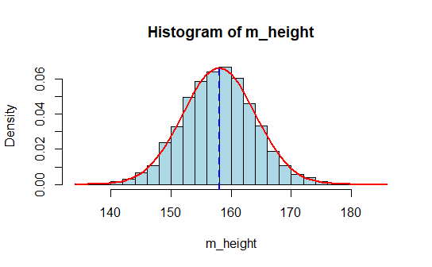

```r
#add the mean line
abline(v = mean(train_data$m_height), col = "blue", lwd = 2, lty = 2)
```

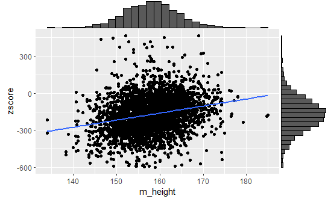

```r
#marginal plot of zscore and m_height
p<- ggplot(train_data, aes(x=m_height, y=zscore)) +
  geom_point() +
  theme(legend.position="none") +
  # add a regression line
  geom_smooth(method=lm, se=FALSE)

p4 <- ggMarginal(p, type="histogram")
p4
```

```r
#plot the distribution of m_bmi variable
hist(train_data$m_bmi, breaks = 20, col = "lightblue", main = "Histogram of m_bmi", xlab = "m_bmi", freq = F)
#add a the density line
lines(density(train_data$m_bmi), col = "red", lwd = 2)
```

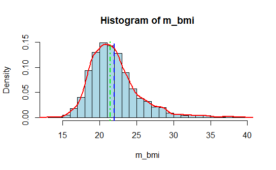

```r
#add the mean line and median line
abline(v = mean(train_data$m_bmi), col = "blue", lwd = 2, lty = 2)
abline(v = median(train_data$m_bmi), col = "green", lwd = 2, lty = 4)
```

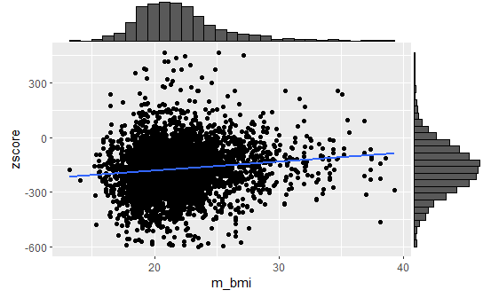

```r
#marginal plot of zscore and m_bmi
p<- ggplot(train_data, aes(x=m_bmi, y=zscore)) +
  geom_point() +
  theme(legend.position="none") +
  # add a regression line
  geom_smooth(method=lm, se=FALSE)

p5 <- ggMarginal(p, type="histogram")
p5
```

Now we plot two histograms of the zscore, one for m_work = 0, and one for m_work = 1, to see if there is a difference in the distribution of the zscore between the two groups.

```r
#table of the number of observations for each value of m_work
table(train_data$m_work)
```

```
   0    1
1670 2087
```

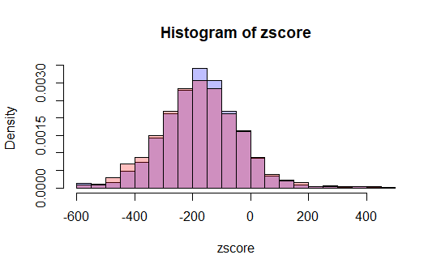

```r
#plot the previous distribution (zscore) for m_work=0 and m_workr=1
hist(train_data$zscore[train_data$m_work==0], breaks = 20, col = rgb(0,0,1,1/4), main = "Histogram of zscore", xlab = "zscore", freq = FALSE)
hist(train_data$zscore[train_data$m_work==1], breaks = 20, col = rgb(1,0,0,1/4), main = "Histogram of zscore", xlab = "zscore", freq = FALSE, add = TRUE)
```

For each value of the variable m_education, we plot the distribution of the zscore.

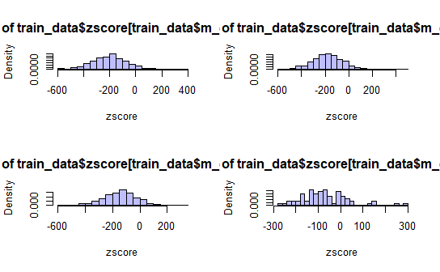

```r
par(mfrow=c(2,2))
#hist of zscore for each value of m_education
for (i in 1:4){
  hist(train_data$zscore[train_data$m_education==i], breaks = 20, col = rgb(0,0,1,1/4), , xlab = "zscore", freq = FALSE)
}
```

NOTE: THIS PLOT WILL BE VERY DIFFERENT WITH R-SHINY, BECAUSE THE PLOT IS INTERACTIVE

FOR REGION AND DISTRICTS CHECK CHOROPLETH MAPS FOR SHINY

Check district repetitions of each district

```r
# Print each value of district (sorted) and the number of repetitions
unique_districts <- unique(train_data$district)
unique_districts <- sort(unique_districts)
for (i in 1:length(unique_districts)){
  print(paste(unique_districts[i], ":", sum(train_data$district == unique_districts[i])))
}
```

```
[1] "12 : 71"
[1] "13 : 85"
[1] "14 : 55"
[1] "15 : 51"
[1] "21 : 17"
[1] "22 : 90"
[1] "23 : 45"
[1] "24 : 32"
[1] "25 : 60"
[1] "26 : 23"
[1] "27 : 66"
[1] "28 : 33"
[1] "31 : 102"
[1] "32 : 38"
[1] "33 : 12"
```

[output cut: 39 more lines]